# Cluster Generation Notes 2

Emily Raney

2022-11-17

## Clusters of equal size

### Runs with positive separation values

#### Run 1

3 clusters of equal size, separation value of 0.01, two non-noisy variables

```r
library(clusterGeneration)
library(tidyverse)
```

```r
library(ggplot2)

genRandomClust(3, sepVal = 0.01, numNonNoisy = 2, numNoisy = 0, numReplicate = 1, fileName = "run1") #generate 3 clusters with a separation value of 0.01

run1_dat <- read.delim("/Users/emilyraney/Documents/clustergen2/clustergen-2/run1_1.dat", sep = " ") #read in .dat file
head(run1_dat)
```

```
##           x1        x2
## 1 -1.0508615 -1.000003
## 2 -0.1646830  1.745007
## 3  2.2313567 -4.100991
## 4  1.4866596  1.168033
## 5  2.3257764 -5.019210
## 6 -0.5207905 -3.286905
```

```r
run1_mem <- read.delim("/Users/emilyraney/Documents/clustergen2/clustergen-2/run1_1.mem", header = FALSE, sep = " ", col.names = "cluster") #read in .mem file; when header is set to TRUE as default, the first row of data is read as the header
head(run1_mem)
```

```
##   cluster
## 1       1
## 2       2
## 3       1
## 4       2
## 5       1
## 6       1
```

```r
run1_comb <- cbind(run1_dat, run1_mem) #combine .dat and .mem files into one dataframe
head(run1_comb)
```

```
##           x1        x2 cluster
## 1 -1.0508615 -1.000003       1
## 2 -0.1646830  1.745007       2
## 3  2.2313567 -4.100991       1
## 4  1.4866596  1.168033       2
## 5  2.3257764 -5.019210       1
## 6 -0.5207905 -3.286905       1
```

```r
class(run1_comb)
```

```
## [1] "data.frame"
```

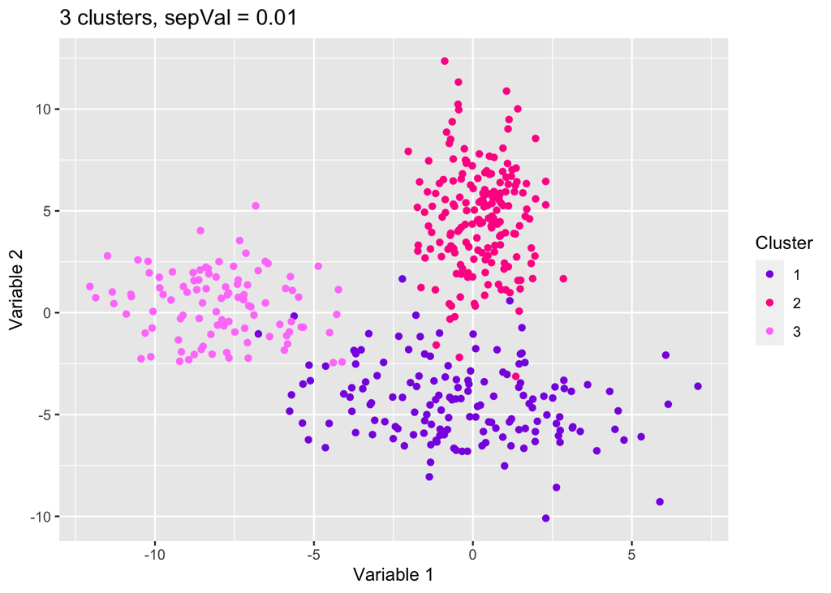

```r
run1_plot <- ggplot(run1_comb, aes(x = x1, y = x2, color = as.factor(cluster))) +geom_point() +scale_color_manual(
  values = c("blueviolet", "deeppink1", "orchid1")) + labs(title = "3 clusters, sepVal = 0.01", color = "Cluster") + xlab("Variable 1") + ylab("Variable 2")
run1_plot
```

#### Run 2

5 clusters of equal size, separation value of 0.01, two non-noisy variables

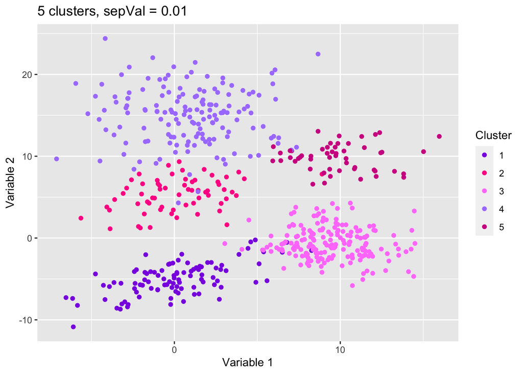

```r
genRandomClust(5, sepVal = 0.01, numNonNoisy = 2, numNoisy = 0, numReplicate = 1, fileName = "run2")

run2_dat <- read.delim("/Users/emilyraney/Documents/clustergen2/clustergen-2/run2_1.dat", sep = " ")
run2_mem <- read.delim("/Users/emilyraney/Documents/clustergen2/clustergen-2/run2_1.mem", header = FALSE, sep = " ", col.names = "cluster")

run2_comb <- cbind(run2_dat, run2_mem)

run2_plot <- ggplot(run2_comb, aes(x = x1, y = x2, color = as.factor(cluster))) +geom_point() +scale_color_manual(
  values = c("blueviolet", "deeppink1", "orchid1", "mediumpurple1", "violetred")) + labs(title = "5 clusters, sepVal = 0.01", color = "Cluster") + xlab("Variable 1") + ylab("Variable 2")
run2_plot
```

#### Run 3

5 clusters of equal size, separation value of 0.25, two non-noisy variables

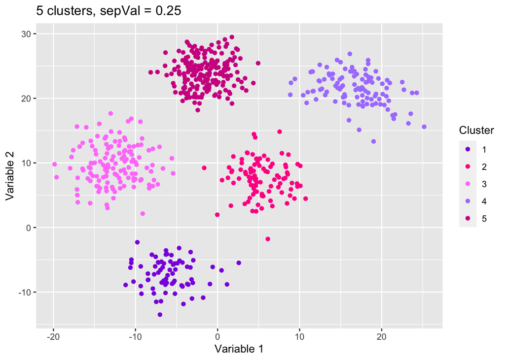

```r
genRandomClust(5, sepVal = 0.25, numNonNoisy = 2, numReplicate = 1, fileName = "run3")

run3_dat <- read.delim("/Users/emilyraney/Documents/clustergen2/clustergen-2/run3_1.dat", sep = " ")
run3_mem <- read.delim("/Users/emilyraney/Documents/clustergen2/clustergen-2/run3_1.mem", header = FALSE, sep = " ", col.names = "cluster")

run3_comb <- cbind(run3_dat, run3_mem)

run3_plot <- ggplot(run3_comb, aes(x = x1, y = x2, color = as.factor(cluster))) +geom_point() +scale_color_manual(
  values = c("blueviolet", "deeppink1", "orchid1", "mediumpurple1", "violetred")) + labs(title = "5 clusters, sepVal = 0.25", color = "Cluster") + xlab("Variable 1") + ylab("Variable 2")
run3_plot
```

#### Run 4

5 clusters of equal size, separation value of .5, two non-noisy variables

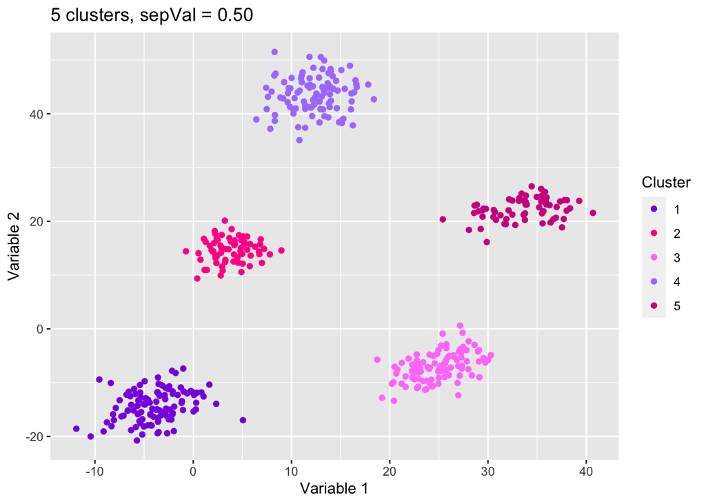

```r
genRandomClust(5, sepVal = 0.5, numNonNoisy = 2, numReplicate = 1, fileName = "run4")

run4_dat <- read.delim("/Users/emilyraney/Documents/clustergen2/clustergen-2/run4_1.dat", sep = " ")
run4_mem <- read.delim("/Users/emilyraney/Documents/clustergen2/clustergen-2/run4_1.mem", header = FALSE, sep = " ", col.names = "cluster")

run4_comb <- cbind(run4_dat, run4_mem)

run4_plot <- ggplot(run4_comb, aes(x = x1, y = x2, color = as.factor(cluster))) +geom_point() +scale_color_manual(
  values = c("blueviolet", "deeppink1", "orchid1", "mediumpurple1", "violetred")) + labs(title = "5 clusters, sepVal = 0.50", color = "Cluster") + xlab("Variable 1") + ylab("Variable 2")
run4_plot
```

#### Run 5

5 clusters of equal size, separation value of 0.75, two non-noisy variables

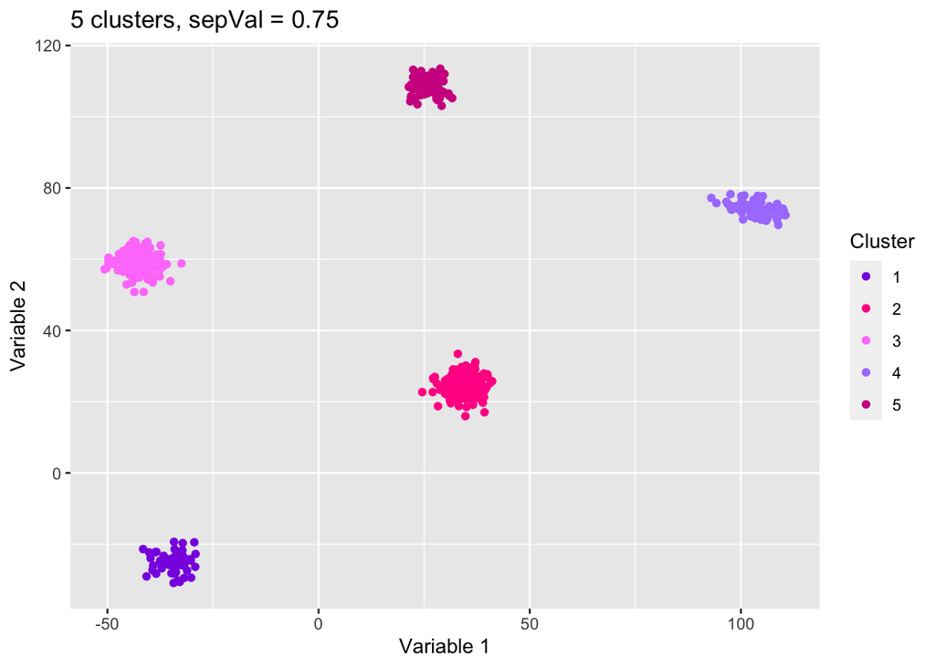

```r
genRandomClust(5, sepVal = 0.75, numNonNoisy = 2, numReplicate = 1, fileName = "run5")

run5_dat <- read.delim("/Users/emilyraney/Documents/clustergen2/clustergen-2/run5_1.dat", sep = " ")
run5_mem <- read.delim("/Users/emilyraney/Documents/clustergen2/clustergen-2/run5_1.mem", header = FALSE, sep = " ", col.names = "cluster")

run5_comb <- cbind(run5_dat, run5_mem)

run5_plot <- ggplot(run5_comb, aes(x = x1, y = x2, color = as.factor(cluster))) +geom_point() +scale_color_manual(
  values = c("blueviolet", "deeppink1", "orchid1", "mediumpurple1", "violetred")) + labs(title = "5 clusters, sepVal = 0.75", color = "Cluster") + xlab("Variable 1") + ylab("Variable 2")
run5_plot
```

#### Run 6

5 clusters of equal size, separation value of 0.99, two non-noisy variables

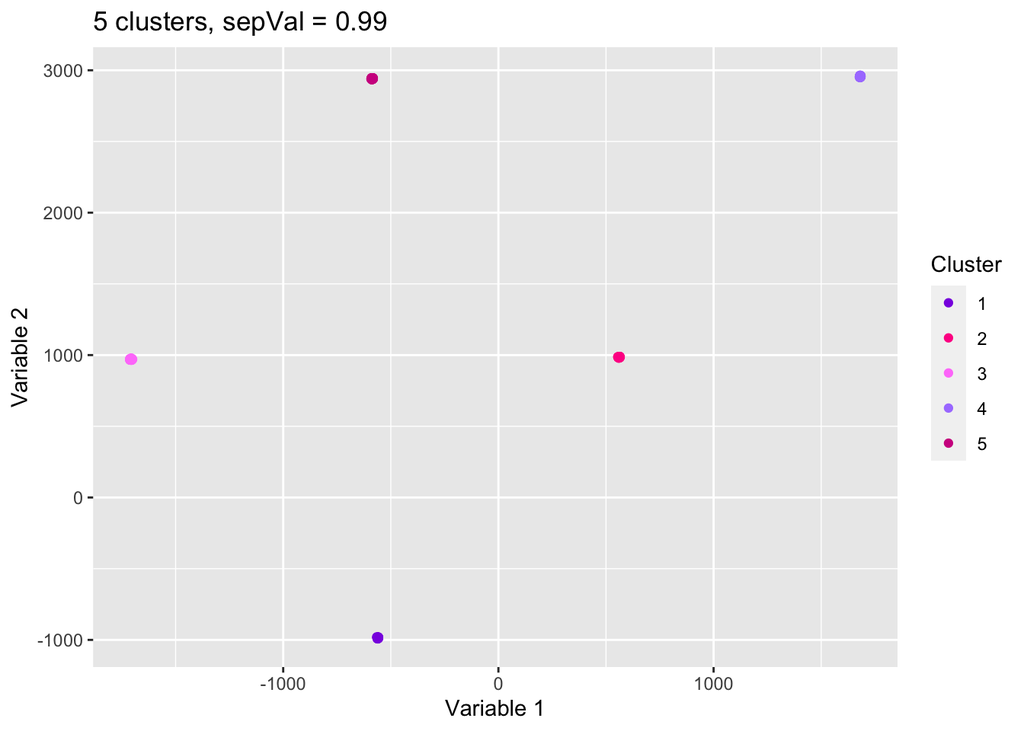

```r
genRandomClust(5, sepVal = 0.99, numNonNoisy = 2, numReplicate = 1, fileName = "run6")

run6_dat <- read.delim("/Users/emilyraney/Documents/clustergen2/clustergen-2/run6_1.dat", sep = " ")
run6_mem <- read.delim("/Users/emilyraney/Documents/clustergen2/clustergen-2/run6_1.mem", header = FALSE, sep = " ", col.names = "cluster")

run6_comb <- cbind(run6_dat, run6_mem)

run6_plot <- ggplot(run6_comb, aes(x = x1, y = x2, color = as.factor(cluster))) +geom_point() +scale_color_manual(
  values = c("blueviolet", "deeppink1", "orchid1", "mediumpurple1", "violetred")) + labs(title = "5 clusters, sepVal = 0.99", color = "Cluster") + xlab("Variable 1") + ylab("Variable 2")
run6_plot
```

### Runs with negative separation values

#### Run 7

5 clusters of equal size, separation value of -0.01, two non-noisy variables

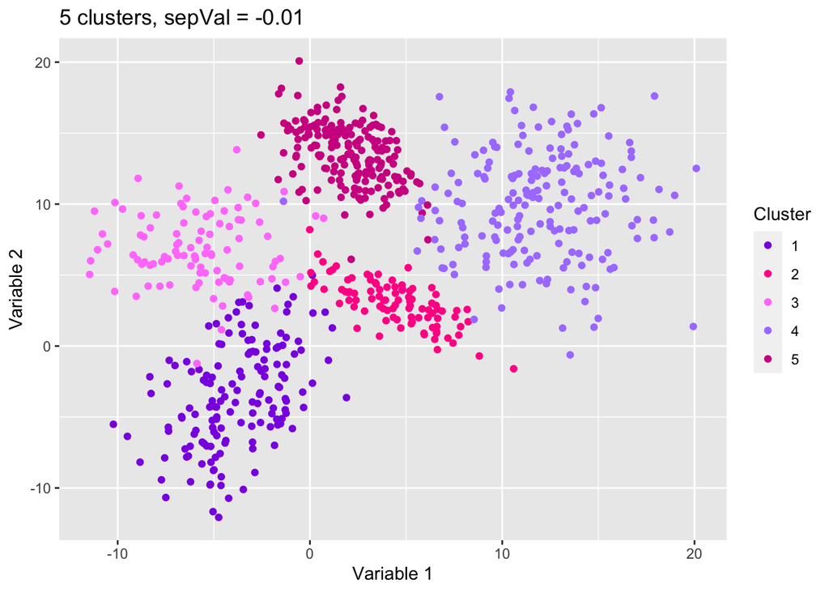

```r
genRandomClust(5, sepVal = -0.01, numNonNoisy = 2, numReplicate = 1, fileName = "run7")

run7_dat <- read.delim("/Users/emilyraney/Documents/clustergen2/clustergen-2/run7_1.dat", sep = " ")
run7_mem <- read.delim("/Users/emilyraney/Documents/clustergen2/clustergen-2/run7_1.mem", header = FALSE, sep = " ", col.names = "cluster")

run7_comb <- cbind(run7_dat, run7_mem)

run7_plot <- ggplot(run7_comb, aes(x = x1, y = x2, color = as.factor(cluster))) +geom_point() +scale_color_manual(
  values = c("blueviolet", "deeppink1", "orchid1", "mediumpurple1", "violetred")) + labs(title = "5 clusters, sepVal = -0.01", color = "Cluster") + xlab("Variable 1") + ylab("Variable 2")
run7_plot
```

#### Run 8

5 clusters of equal size, separation value of -0.25, two non-noisy variables

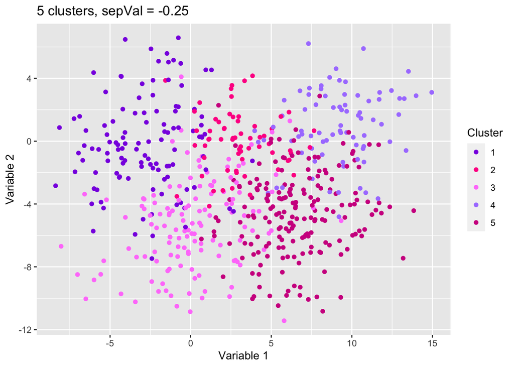

```r
genRandomClust(5, sepVal = -0.25, numNonNoisy = 2, numReplicate = 1, fileName = "run8")

run8_dat <- read.delim("/Users/emilyraney/Documents/clustergen2/clustergen-2/run8_1.dat", sep = " ")
run8_mem <- read.delim("/Users/emilyraney/Documents/clustergen2/clustergen-2/run8_1.mem", header = FALSE, sep = " ", col.names = "cluster")

run8_comb <- cbind(run8_dat, run8_mem)

run8_plot <- ggplot(run8_comb, aes(x = x1, y = x2, color = as.factor(cluster))) +geom_point() +scale_color_manual(
  values = c("blueviolet", "deeppink1", "orchid1", "mediumpurple1", "violetred")) + labs(title = "5 clusters, sepVal = -0.25", color = "Cluster") + xlab("Variable 1") + ylab("Variable 2")
run8_plot
```

#### Run 9

5 clusters of equal size, separation value of -0.50, two non-noisy variables

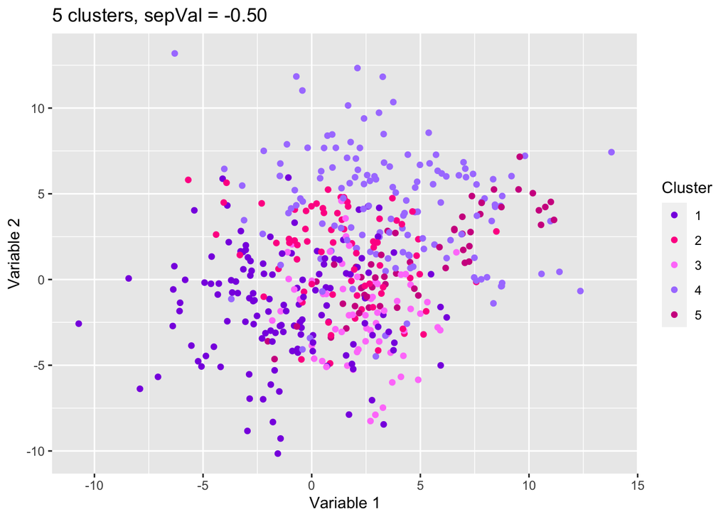

```r
genRandomClust(5, sepVal =  -0.5, numNonNoisy = 2, numReplicate = 1, fileName = "run9")

run9_dat <- read.delim("/Users/emilyraney/Documents/clustergen2/clustergen-2/run9_1.dat", sep = " ")
run9_mem <- read.delim("/Users/emilyraney/Documents/clustergen2/clustergen-2/run9_1.mem", header = FALSE, sep = " ", col.names = "cluster")

run9_comb <- cbind(run9_dat, run9_mem)

run9_plot <- ggplot(run9_comb, aes(x = x1, y = x2, color = as.factor(cluster))) +geom_point() +scale_color_manual(
  values = c("blueviolet", "deeppink1", "orchid1", "mediumpurple1", "violetred")) + labs(title = "5 clusters, sepVal = -0.50", color = "Cluster") + xlab("Variable 1") + ylab("Variable 2")
run9_plot
```

#### Run 10

5 clusters of equal size, separation value of -0.75, two non-noisy variables

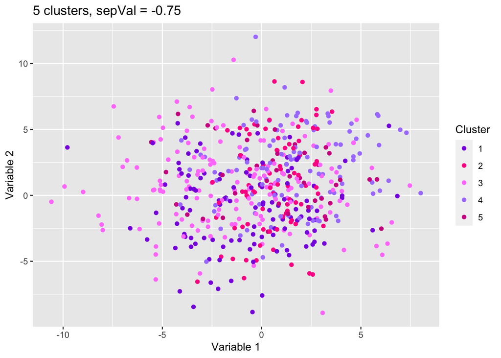

```r
genRandomClust(5, sepVal =  -0.75, numNonNoisy = 2, numReplicate = 1, fileName = "run10")

run10_dat <- read.delim("/Users/emilyraney/Documents/clustergen2/clustergen-2/run10_1.dat", sep = " ")
run10_mem <- read.delim("/Users/emilyraney/Documents/clustergen2/clustergen-2/run10_1.mem", header = FALSE, sep = " ", col.names = "cluster")

run10_comb <- cbind(run10_dat, run10_mem)

run10_plot <- ggplot(run10_comb, aes(x = x1, y = x2, color = as.factor(cluster))) +geom_point() +scale_color_manual(
  values = c("blueviolet", "deeppink1", "orchid1", "mediumpurple1", "violetred")) + labs(title = "5 clusters, sepVal = -0.75", color = "Cluster") + xlab("Variable 1") + ylab("Variable 2")
run10_plot
```

#### Run 11

5 clusters of equal size, separation value of -0.99, two non-noisy variables

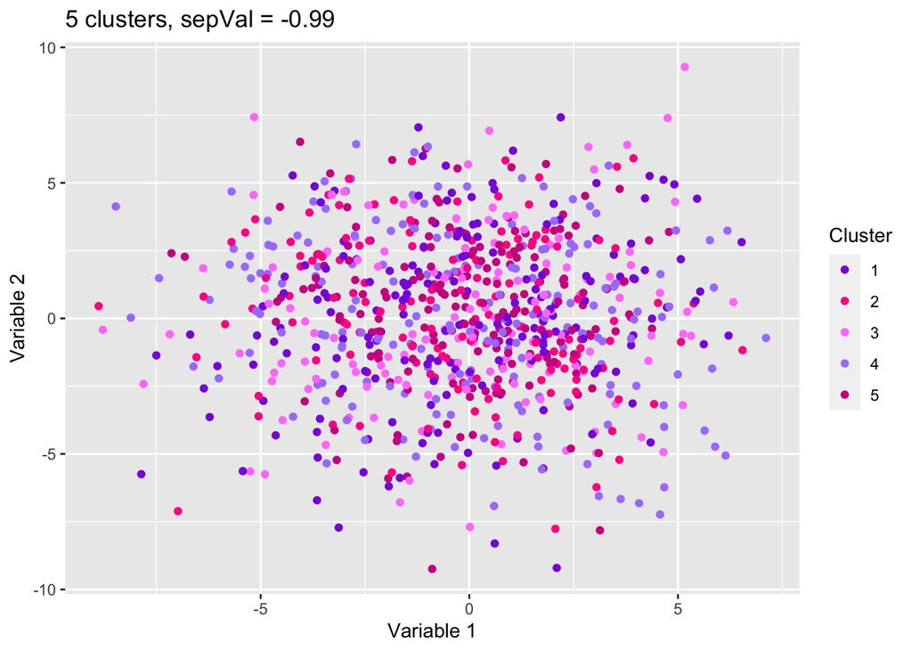

```r
genRandomClust(5, sepVal =  -0.99, numNonNoisy = 2, numReplicate = 1, fileName = "run11")

run11_dat <- read.delim("/Users/emilyraney/Documents/clustergen2/clustergen-2/run11_1.dat", sep = " ")
run11_mem <- read.delim("/Users/emilyraney/Documents/clustergen2/clustergen-2/run11_1.mem", header = FALSE, sep = " ", col.names = "cluster")

run11_comb <- cbind(run11_dat, run11_mem)

run11_plot <- ggplot(run11_comb, aes(x = x1, y = x2, color = as.factor(cluster))) +geom_point() +scale_color_manual(
  values = c("blueviolet", "deeppink1", "orchid1", "mediumpurple1", "violetred")) + labs(title = "5 clusters, sepVal = -0.99", color = "Cluster") + xlab("Variable 1") + ylab("Variable 2")
run11_plot
```

## Clusters of unequal size

### Clusters with positive separation values

#### Run 12

5 clusters of unequal size; there us a user-set range of values (10-50) but the resulting cluster sizes are random. Separation value of 0.01, two non-noisy variables.

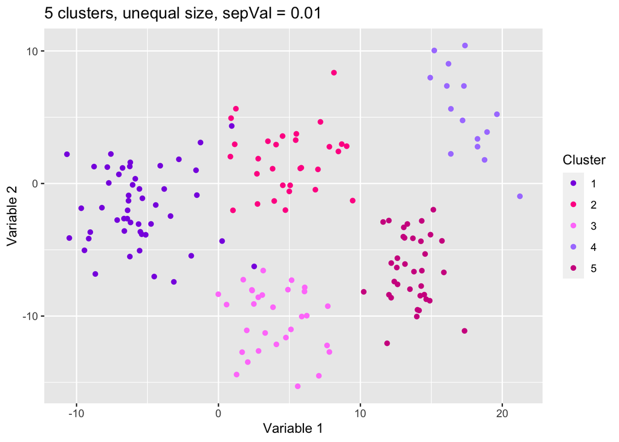

```r
genRandomClust(5, sepVal = 0.01, numNonNoisy = 2, clustszind = 2, rangeN = c(10, 50), numReplicate = 1, fileName = "run12") #set cluster sizes to be unequal [clustsizind = 2], with a range of values from 10-50 [rangeN = 10-50]; the sizes of each cluster can be found in the .log file.

run12_dat <- read.delim("/Users/emilyraney/Documents/clustergen2/clustergen-2/run12_1.dat", sep = " ")
run12_mem <- read.delim("/Users/emilyraney/Documents/clustergen2/clustergen-2/run12_1.mem", header = FALSE, sep = " ", col.names = "cluster")

run12_comb <- cbind(run12_dat, run12_mem)

run12_plot <- ggplot(run12_comb, aes(x = x1, y = x2, color = as.factor(cluster))) +geom_point() +scale_color_manual(
  values = c("blueviolet", "deeppink1", "orchid1", "mediumpurple1", "violetred")) + labs(title = "5 clusters, unequal size, sepVal = 0.01", color = "Cluster") + xlab("Variable 1") + ylab("Variable 2")
run12_plot
```

#### Run 13

5 clusters of unequal size; user-defined sizes for each cluster [clustszind = 3, clustSizes = c(3, 9, 12, 18, 50)]. Separation value of 0.01, two non-noisy variables.

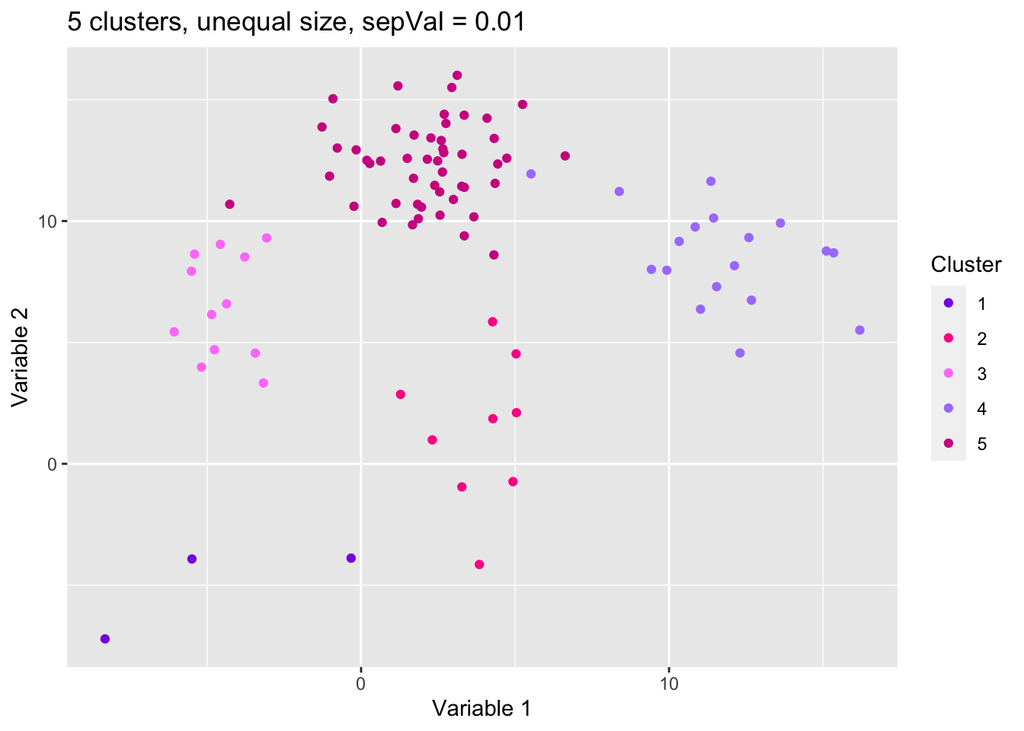

```r
genRandomClust(5, sepVal = 0.01, numNonNoisy = 2, clustszind = 3, clustSizes = c(3, 9, 12, 18, 50), numReplicate = 1, fileName = "run13")

run13_dat <- read.delim("/Users/emilyraney/Documents/clustergen2/clustergen-2/run13_1.dat", sep = " ")
run13_mem <- read.delim("/Users/emilyraney/Documents/clustergen2/clustergen-2/run13_1.mem", header = FALSE, sep = " ", col.names = "cluster")

run13_comb <- cbind(run13_dat, run13_mem)

run13_plot <- ggplot(run13_comb, aes(x = x1, y = x2, color = as.factor(cluster))) +geom_point() +scale_color_manual(
  values = c("blueviolet", "deeppink1", "orchid1", "mediumpurple1", "violetred")) + labs(title = "5 clusters, unequal size, sepVal = 0.01", color = "Cluster") + xlab("Variable 1") + ylab("Variable 2")
run13_plot
```